# Olympics 2016 Analytics

The **Rio 2016 Olympics** was a landmark event, marking the **first time the Olympic Games were hosted in South America.** Held in **Rio de Janeiro, Brazil, from August 5 to 21, 2016,** the event brought together athletes from across the globe, competing in a wide array of sports. The games featured a mix of traditional Olympic sports and newer ones like rugby sevens and golf, drawing attention from millions worldwide.

[figure not shown]

### **| Features**

1. **`ID` [numeric]:** A unique identifier for each athlete.
2. **`Name` [categorical]:** The full name of the athlete.
3. **`Nationality` [categorical]:** The nationality of the athlete, indicating their country of origin.
4. **`Sex` [categorical]:** The gender of the athlete (M for Male, F for Female).
5. **`DOB (Date of Birth)` [Date]:** The birthdate of the athlete.
6. **`Height` [numeric]:** The height of the athlete (in meters).
7. **`Weight` [numeric]:** The weight of the athlete (in kilograms).
8. **`Sport` [categorical]:** The sport in which the athlete competed.
9. **`Gold, Silver, Bronze` [categorical]:** These columns indicate the number of gold, silver, and bronze medals won by the athlete.

### **| Libraries**

```python
import numpy as np
import pandas as pd
import matplotlib.pyplot as plt
import seaborn as sns
```

```python
sns.set_palette("GnBu_d")
sns.set_style('whitegrid')
```

### **| EDA**

```python
df = pd.read_csv(r"C:\Users\user\Downloads\athletes.csv")
```

```python
df.shape
```

```
(11538, 11)
```

```python
df.head()
```

|  | id | name | nationality | sex | dob | height | weight | sport | gold | silver | bronze |
| --- | --- | --- | --- | --- | --- | --- | --- | --- | --- | --- | --- |
| 0 | 736041664 | A Jesus Garcia | ESP | male | 10/17/69 | 1.72 | 64.0 | athletics | 0 | 0 | 0 |
| 1 | 532037425 | A Lam Shin | KOR | female | 9/23/86 | 1.68 | 56.0 | fencing | 0 | 0 | 0 |
| 2 | 435962603 | Aaron Brown | CAN | male | 5/27/92 | 1.98 | 79.0 | athletics | 0 | 0 | 1 |
| 3 | 521041435 | Aaron Cook | MDA | male | 1/2/91 | 1.83 | 80.0 | taekwondo | 0 | 0 | 0 |
| 4 | 33922579 | Aaron Gate | NZL | male | 11/26/90 | 1.81 | 71.0 | cycling | 0 | 0 | 0 |

```python
df.tail()
```

|  | id | name | nationality | sex | dob | height | weight | sport | gold | silver | bronze |
| --- | --- | --- | --- | --- | --- | --- | --- | --- | --- | --- | --- |
| 11533 | 265605954 | Zurian Hechavarria | CUB | female | 8/10/95 | 1.64 | 58.0 | athletics | 0 | 0 | 0 |
| 11534 | 214461847 | Zuzana Hejnova | CZE | female | 12/19/86 | 1.73 | 63.0 | athletics | 0 | 0 | 0 |
| 11535 | 88361042 | di Xiao | CHN | male | 5/14/91 | 1.85 | 100.0 | wrestling | 0 | 0 | 0 |
| 11536 | 900065925 | le Quoc Toan Tran | VIE | male | 4/5/89 | 1.60 | 56.0 | weightlifting | 0 | 0 | 0 |
| 11537 | 711404576 | le Roux Hamman | RSA | male | 1/6/92 | 1.85 | 70.0 | athletics | 0 | 0 | 0 |

```python
df.info()
```

```
<class 'pandas.core.frame.DataFrame'>
RangeIndex: 11538 entries, 0 to 11537
Data columns (total 11 columns):
 #   Column       Non-Null Count  Dtype
---  ------       --------------  -----
 0   id           11538 non-null  int64
 1   name         11538 non-null  object
 2   nationality  11538 non-null  object
 3   sex          11538 non-null  object
 4   dob          11537 non-null  object
 5   height       11208 non-null  float64
 6   weight       10879 non-null  float64
 7   sport        11538 non-null  object
 8   gold         11538 non-null  int64
 9   silver       11538 non-null  int64
 10  bronze       11538 non-null  int64
dtypes: float64(2), int64(4), object(5)
memory usage: 991.7+ KB
```

```python
# Find and count duplicate records if any
num_of_duplicates = len(df[df.duplicated()])
print("Number of duplicate records:", num_of_duplicates)
```

```
Number of duplicate records: 0
```

```python
df.isnull().sum()
```

```
id               0
name             0
nationality      0
sex              0
dob              1
height         330
weight         659
sport            0
gold             0
silver           0
bronze           0
dtype: int64
```

```python
df['sport'].unique()
```

```
array(['athletics', 'fencing', 'taekwondo', 'cycling', 'triathlon',
       'volleyball', 'aquatics', 'rugby sevens', 'wrestling', 'football',
       'shooting', 'boxing', 'equestrian', 'rowing', 'judo', 'handball',
       'badminton', 'hockey', 'modern pentathlon', 'table tennis',
       'canoe', 'basketball', 'golf', 'archery', 'weightlifting',
       'sailing', 'tennis', 'gymnastics'], dtype=object)
```

```python
df['nationality'].unique()
```

```
array(['ESP', 'KOR', 'CAN', 'MDA', 'NZL', 'AUS', 'USA', 'ETH', 'BRN',
       'IOA', 'GBR', 'UZB', 'RSA', 'EGY', 'MAR', 'QAT', 'SUD', 'ALG',
       'DEN', 'NED', 'DJI', 'SEN', 'CMR', 'ITA', 'NIG', 'SWE', 'GHA',
       'AFG', 'AZE', 'KSA', 'BAN', 'NGR', 'RUS', 'IND', 'HUN', 'KAZ',
       'BDI', 'ERI', 'POL', 'BRA', 'GEO', 'CZE', 'SEY', 'GAM', 'LTU',
       'IRI', 'ROU', 'CUB', 'SLO', 'BAH', 'ARG', 'PUR', 'FRA', 'RWA',
       'TOG', 'MDV', 'TUN', 'ISR', 'LAT', 'JOR', 'MAS', 'LIB', 'LBA',
       'PLE', 'IRQ', 'TUR', 'VEN', 'JPN', 'TPE', 'KGZ', 'CHN', 'MEX',
       'GRE', 'IRL', 'JAM', 'SUI', 'BAR', 'HON', 'ANG', 'GER', 'COL',
       'URU', 'MNE', 'SRB', 'BUL', 'FIN', 'UKR', 'BLR', 'SMR', 'COK',
       'SAM', 'AUT', 'BEL', 'KEN', 'SVK', 'POR', 'ECU', 'UAE', 'NAM',
       'GUY', 'EST', 'SKN', 'ARU', 'PAN', 'PER', 'TAN', 'FIJ', 'GUI',
       'NOR', 'ARM', 'THA', 'SIN', 'TKM', 'CRO', 'BIH', 'TGA', 'MAW',
       'DOM', 'GUA', 'MKD', 'TJK', 'CYP', 'CHI', 'MLT', 'ZIM', 'TTO',
       'CRC', 'BOL', 'BUR', 'ISL', 'HAI', 'ROT', 'MGL', 'MAD', 'GAB',
       'SRI', 'LAO', 'MRI', 'PAR', 'IVB', 'GBS', 'TLS', 'MLI', 'SYR',
       'BOT', 'CHA', 'OMA', 'COD', 'CIV', 'GEQ', 'UGA', 'GUM', 'ASA',
       'ZAM', 'VAN', 'GRN', 'BIZ', 'VIN', 'MON', 'ALB', 'STP', 'SLE',
       'BER', 'HKG', 'ISV', 'CGO', 'ANT', 'BEN', 'LUX', 'PHI', 'CAF',
       'PRK', 'LIE', 'MHL', 'NCA', 'KIR', 'CPV', 'INA', 'FSM', 'COM',
       'PLW', 'MYA', 'NRU', 'LBR', 'ESA', 'AND', 'TUV', 'SUR', 'CAY',
       'NEP', 'PAK', 'SSD', 'MTN', 'VIE', 'MOZ', 'LES', 'LCA', 'BRU',
       'SOL', 'BHU', 'CAM', 'KOS', 'SOM', 'PNG', 'YEM', 'SWZ', 'DMA'],
      dtype=object)
```

```python
number_of_athletes = df['id'].nunique()
number_of_sports = df['sport'].nunique()
number_of_nationalities = df['nationality'].nunique()
number_of_gold_medals = df['gold'].sum()
number_of_silver_medals = df['silver'].sum()
number_of_bronze_medals = df['bronze'].sum()
```

```python
print(f"{number_of_athletes} athletes have participated in Olympics 2016 in Rio de Janeiro through {number_of_sports} sports representing {number_of_nationalities} nationalities." )
print(f"They have achieved a total of {number_of_gold_medals} gold medals, {number_of_silver_medals} silver medals and {number_of_bronze_medals} bronze medals").
```

```
11538 athletes have participated in Olympics 2016 in Rio de Janeiro through 28 sports representing 207 nationalities.
They have achieved a total of 666 gold medals, 655 silver medals and 704 bronze medals
```

```python
print("\nTop countries by number of athletes:")
top_countries = df['nationality'].value_counts().head(10)
print(top_countries)
```

```
Top countries by number of athletes:
nationality
USA    567
BRA    485
GER    441
AUS    431
FRA    410
CHN    404
GBR    374
JPN    346
CAN    321
ESP    313
Name: count, dtype: int64
```

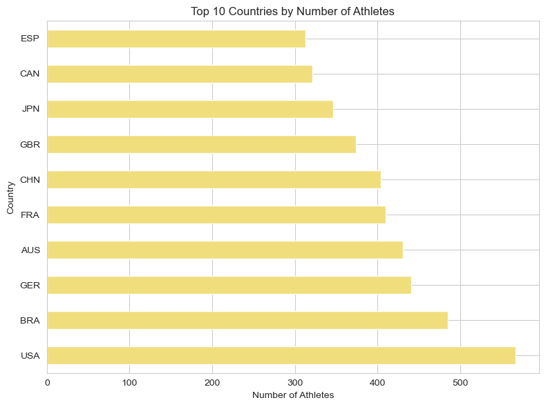

```python
# Visualization: Bar chart for top 10 countries
fig, ax = plt.subplots(figsize=(8, 6))

top_countries.plot(kind='barh', ax=ax, color='#f0de7d')

ax.set_title('Top 10 Countries by Number of Athletes')
ax.set_xlabel('Number of Athletes')
ax.set_ylabel('Country')

plt.tight_layout()
plt.show()
```

### **| Countries with the most medals**

```python
# Countries with the most medals
print("\nTop countries by total medals:")
medal_counts = df.groupby('nationality')[['gold', 'silver', 'bronze']].sum().sort_values(by=['gold', 'silver', 'bronze'], ascending=False)
print(medal_counts.head(10))
```

```
Top countries by total medals:
             gold  silver  bronze
nationality
USA           139      54      71
GBR            64      55      26
RUS            52      29      34
GER            49      44      67
CHN            46      30      37
BRA            37       8       6
AUS            23      34      25
ARG            21       1       0
FRA            20      54      21
JPN            17      13      35
```

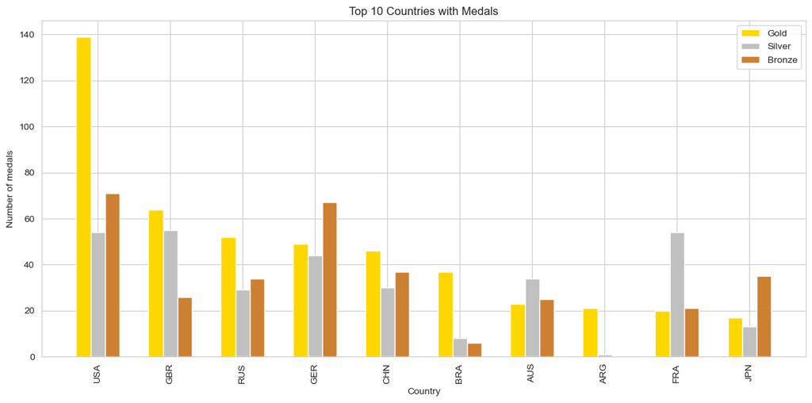

```python
fig, ax = plt.subplots(figsize=(12, 6))
x = np.arange(len(medal_counts.head(10).index))
width = 0.2

ax.bar(x - width, medal_counts.head(10)['gold'], width, color='gold', label='Gold')
ax.bar(x, medal_counts.head(10)['silver'], width, color='silver', label='Silver')
ax.bar(x + width, medal_counts.head(10)['bronze'], width, color='#CD7F32', label='Bronze')

ax.set_xticks(x)
ax.set_xticklabels(medal_counts.head(10).index, rotation=90)
ax.set_title('Top 10 Countries with Medals')
ax.set_xlabel('Country')
ax.set_ylabel('Number of medals')
ax.legend()

plt.tight_layout()
plt.show()
```

```python
top_countries_dict = {}

# Loop through each unique sport and get the top 3 countries
for sport in df['sport'].unique():
    sport_df = df[df['sport'] == sport]
    top_countries = sport_df.groupby('nationality')[['gold', 'silver', 'bronze']].sum().sort_values(by=['gold', 'silver', 'bronze'], ascending=False).head(3)
    top_countries_dict[sport] = ', '.join(top_countries.index)

# Convert the dictionary to a dataframe
top_countries_df = pd.DataFrame.from_dict(top_countries_dict, orient='index', columns=['Top 3 Countries'])

top_countries_df.style.background_gradient(cmap='Purples')
```

|  | Top 3 Countries |
| --- | --- |
| athletics | USA, JAM, KEN |
| fencing | RUS, FRA, ROU |
| taekwondo | KOR, CHN, GBR |
| cycling | GBR, USA, NED |
| triathlon | GBR, USA, SUI |
| volleyball | BRA, CHN, GER |
| aquatics | USA, SRB, CHN |
| rugby sevens | FIJ, AUS, GBR |
| wrestling | RUS, JPN, CUB |
| football | GER, BRA, SWE |
| shooting | ITA, GER, CHN |
| boxing | UZB, CUB, FRA |
| equestrian | FRA, GER, GBR |
| rowing | GBR, USA, GER |
| judo | JPN, FRA, RUS |
| handball | RUS, DEN, FRA |
| badminton | CHN, JPN, INA |
| hockey | ARG, GBR, BEL |
| modern pentathlon | AUS, RUS, FRA |
| table tennis | CHN, JPN, GER |
| canoe | GER, HUN, ESP |
| basketball | USA, ESP, SRB |
| golf | GBR, KOR, NZL |
| archery | KOR, USA, RUS |
| weightlifting | CHN, THA, IRI |
| sailing | GBR, NZL, CRO |
| tennis | USA, ESP, RUS |
| gymnastics | USA, RUS, JPN |

### **| Athletes with the most medals**

```python
# Get the top athletes ranked by gold, silver, and bronze medals
top_athletes = (
    df.groupby('name')
    [['gold', 'silver', 'bronze']]
    .sum()
    .assign(total_medals=lambda x: x['gold'] + x['silver'] + x['bronze'])
    .sort_values(['gold', 'silver', 'bronze'], ascending=False)
    .reset_index()
    .reset_index(drop=False)
    .rename(columns={'index': 'rank'})
)

print(top_athletes.head(10))
```

```
   rank             name  gold  silver  bronze  total_medals
0     0   Michael Phelps     5       1       0             6
1     1    Katie Ledecky     4       1       0             5
2     2     Simone Biles     4       0       1             5
3     3   Katinka Hosszu     3       1       0             4
4     4     Danuta Kozak     3       0       0             3
5     5      Jason Kenny     3       0       0             3
6     6      Ryan Murphy     3       0       0             3
7     7       Usain Bolt     3       0       0             3
8     8    Simone Manuel     2       2       0             4
9     9  Madeline Dirado     2       1       1             4
```

### **| Gender, Height & Weight**

[figure not shown]

```python
fig, ax = plt.subplots()

class_counts = df['sex'].value_counts()

labels = ['female', 'male']
colors = ['#fe346e', '#6e6d6d']

# Create a bar plot
plt.bar(labels, class_counts.values, color=colors, width = 0.4)

plt.xlabel('')
plt.ylabel('Number of Athletes')
plt.title('Distribution of Athletes Gender')
plt.show()
```

```python
def plot_histogram(data, column_name, bins=20, kde=True, alpha=1):
    sns.histplot(data[column_name], bins=bins, kde=kde, alpha=alpha, color = '#f0de7d')

    plt.title(f'{column_name} Distribution')
    plt.xlabel(column_name)
    plt.ylabel('Density')

    plt.show()
```

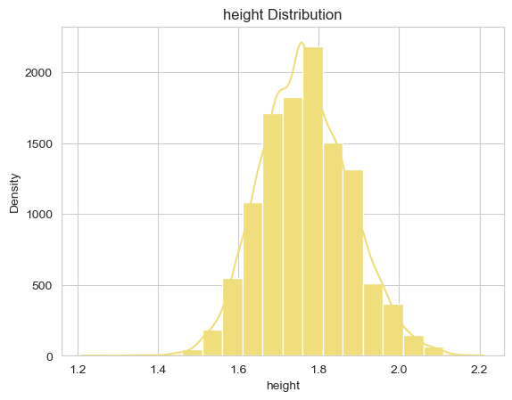

```python
plot_histogram(df, 'height')
```

[figure not shown]

```python
plot_histogram(df, 'height')
```

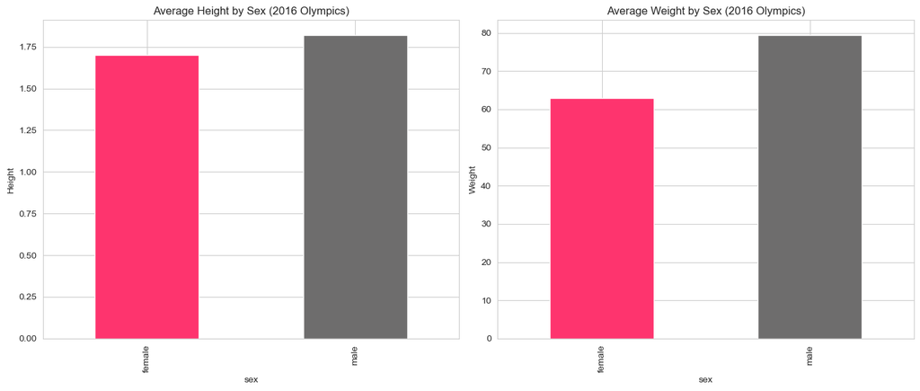

```python
# Create a figure with two subplots
fig, ax = plt.subplots(1, 2, figsize=(14, 6))

# Group by 'sex' and calculate mean 'height'
mean_heights = df.groupby('sex')['height'].mean()

# Plot average height
colors = {'male': '#6e6d6d', 'female': '#fe346e'}
mean_heights.plot(kind='bar', color=[colors[sex] for sex in mean_heights.index], ax=ax[0])
ax[0].set_ylabel('Height')
ax[0].set_title('Average Height by Sex (2016 Olympics)')

# Group by 'sex' and calculate mean 'weight'
mean_weights = df.groupby('sex')['weight'].mean()

# Plot average weight
mean_weights.plot(kind='bar', color=[colors[sex] for sex in mean_weights.index], ax=ax[1])
ax[1].set_ylabel('Weight')
ax[1].set_title('Average Weight by Sex (2016 Olympics)')

plt.tight_layout()
plt.show()
```

```python
mean_height_male = mean_heights.get('male', 0)
mean_height_female = mean_heights.get('female', 0)
mean_weight_male = mean_weights.get('male', 0)
mean_weight_female = mean_weights.get('female', 0)

# Print comparison statement
print(f"Average Heights:\n"
      f" - Males: {mean_height_male:.2f} cm\n"
      f" - Females: {mean_height_female:.2f} cm\n"
      f"Average Weights:\n"
      f" - Males: {mean_weight_male:.2f} kg\n"
      f" - Females: {mean_weight_female:.2f} kg")


print("\nMales are on average taller than females.")
print("Males are on average heavier than females.")
```

[output not shown]

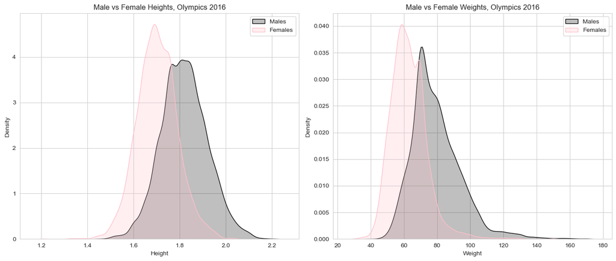

```python
fig, axs = plt.subplots(1, 2, figsize=(14, 6))

# KDE plot for height
sns.kdeplot(data=df[df['sex'] == 'male']['height'], color='black', fill=True, label='Males', ax=axs[0])
sns.kdeplot(data=df[df['sex'] == 'female']['height'], color='pink', fill=True, label='Females', ax=axs[0])
axs[0].set_xlabel('Height')
axs[0].set_ylabel('Density')
axs[0].set_title('Male vs Female Heights, Olympics 2016')
axs[0].legend()

# KDE plot for weight
sns.kdeplot(data=df[df['sex'] == 'male']['weight'], color='black', fill=True, label='Males', ax=axs[1])
sns.kdeplot(data=df[df['sex'] == 'female']['weight'], color='pink', fill=True, label='Females', ax=axs[1])
axs[1].set_xlabel('Weight')
axs[1].set_ylabel('Density')
axs[1].set_title('Male vs Female Weights, Olympics 2016')
axs[1].legend()

plt.tight_layout()
plt.show()
```

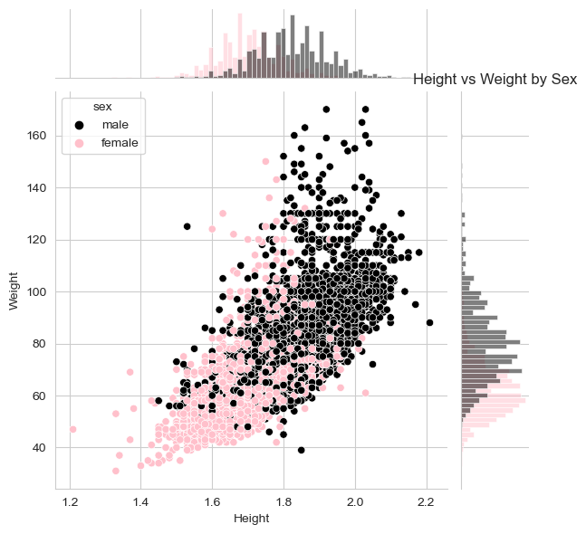

```python
g = sns.JointGrid(x='height', y='weight', data=df)
g.plot_joint(sns.scatterplot, hue=df['sex'], palette={'male': 'black', 'female': 'pink'})
g.plot_marginals(sns.histplot, hue=df['sex'], palette={'male': 'black', 'female': 'pink'})

# Set labels and title
g.set_axis_labels('Height', 'Weight')
plt.title('Height vs Weight by Sex')
```